# Estudios de Informática, Multimedia y Telecomunicaciones

# Minería de datos: PEC1

Autor: Leonardo Segovia Vilchez

Marzo 2020

# 1 Introducción

## 1.1 Presentación

Esta prueba de evaluación continuada cubre el módulo 1,2 y 8 del programa de la asignatura.

## 1.2 Competencias

Las competencias que se trabajan en esta prueba son:

- Uso y aplicación de las TIC en el ámbito académico y profesional
- Capacidad para innovar y generar nuevas ideas.
- Capacidad para evaluar soluciones tecnológicas y elaborar propuestas de proyectos teniendo en cuenta los recursos, las alternativas disponibles y las condiciones de mercado.
- Conocer las tecnologías de comunicaciones actuales y emergentes, así como saberlas aplicar convenientemente para diseñar y desarrollar soluciones basadas en sistemas y tecnologías de la información.
- Aplicación de las técnicas específicas de ingeniería del software en las diferentes etapas del ciclo de vida de un proyecto.
- Capacidad para aplicar las técnicas específicas de tratamiento, almacenamiento y administración de datos.
- Capacidad para proponer y evaluar diferentes alternativas tecnológicas para resolver un problema concreto.
- Capacidad de utilizar un lenguaje de programación.
- Capacidad para desarrollar en una herramienta IDE.
- Capacidad de plantear un proyecto de minería de datos.

## 1.3 Objetivos

- Asimilar correctamente el módulo 1 y 2.
- Qué es y qué no es MD.
- Ciclo de vida de los proyectos de MD.
- Diferentes tipologías de MD.
- Conocer las técnicas propias de una fase de preparación de datos y objetivos a alcanzar.

## 1.4 Descripción de la PEC a realizar

La prueba está estructurada en 1 ejercicio teórico/práctico y 1 ejercicio práctico que pide que se desarrolle la fase de preparación en un juego de datos.  
Deben responderse todos los ejercicios para poder superar la PEC.

## 1.5 Recursos

Para realizar esta práctica recomendamos la lectura de los siguientes documentos:

- Módulo 1, 2 y 8 del material didáctico.
- RStudio Cheat Sheet: Disponible en el aula Laboratorio de Minería de datos.
- R Base Cheat Sheet: Disponible en el aula Laboratorio de Minería de datos.

## 1.6 Criterios de evaluación

**Ejercicios teóricos**  
Todos los ejercicios deben ser presentados de forma razonada y clara, especificando todos y cada uno de los pasos que se hayan llevado a cabo para su resolución. No se aceptará ninguna respuesta que no esté claramente justificada.

**Ejercicios prácticos**  
Para todas las PEC es necesario documentar en cada apartado del ejercicio práctico qué se ha hecho y cómo se ha hecho.

## 1.7 Formato y fecha de entrega

El formato de entrega es: usernameestudiant-PECn.html y rmd  
Fecha de Entrega: 01/04/2020  
Se debe entregar la PEC en el buzón de entregas del aula

## 1.8 Nota: Propiedad intelectual

> A menudo es inevitable, al producir una obra multimedia, hacer uso de recursos creados por terceras personas. Es por lo tanto comprensible hacerlo en el marco de una práctica de los estudios de Informática, Multimedia y Telecomunicación de la UOC, siempre y cuando esto se documente claramente y no suponga plagio en la práctica.

> Por lo tanto, al presentar una práctica que haga uso de recursos ajenos, se debe presentar junto con ella un documento en qué se detallen todos ellos, especificando el nombre de cada recurso, su autor, el lugar dónde se obtuvo y su estatus legal: si la obra está protegida por el copyright o se acoge a alguna otra licencia de uso (Creative Commons, licencia GNU, GPL …). El estudiante deberá asegurarse de que la licencia no impide específicamente su uso en el marco de la práctica. En caso de no encontrar la información correspondiente tendrá que asumir que la obra está protegida por copyright.

> Deberéis, además, adjuntar los ficheros originales cuando las obras utilizadas sean digitales, y su código fuente si corresponde.

# 2 Enunciado

Como ejemplo, trabajaremos con el conjunto de datos “Titanic” que recoge datos sobre el famoso crucero y sobre el que es fácil realizar tareas de clasificación predictiva sobre la variable “Survived”.

De momento dejaremos para las siguientes prácticas el estudio de algoritmos predictivos y nos centraremos por ahora en el estudio de las variables de una muestra de datos, es decir, haremos un trabajo descriptivo del mismo.

Las actividades que llevaremos a cabo en esta práctica suelen enmarcarse en las fases iniciales de un proyecto de minería de datos y consisten en la selección de características o variables y la preparación del los datos para posteriormente ser consumido por un algoritmo.

Las técnicas que trabajaremos son las siguientes:

1. Normalización
2. Discretización
3. Gestión de valores nulos
4. Estudio de correlaciones
5. Reducción de la dimensionalidad
6. Análisis visual del conjunto de datos

# 3 Ejemplo de estudio visual con el juego de datos Titanic

## 3.1 Procesos de limpieza del conjunto de datos

Primer contacto con el conjunto de datos, visualizamos su estructura.

```r
# Cargamos los paquetes R que vamos a usar
library(ggplot2)
library(dplyr)

# Cargamos el fichero de datos
totalData <- read.csv('titanic.csv',stringsAsFactors = FALSE)
filas=dim(totalData)[1]

# Verificamos la estructura del conjunto de datos
str(totalData)
```

```
## 'data.frame':    2207 obs. of  11 variables:
##  $ name    : chr  "Abbing, Mr. Anthony" "Abbott, Mr. Eugene Joseph" "Abbott, Mr. Rossmore Edward" "Abbott, Mrs. Rhoda Mary 'Rosa'" ...
##  $ gender  : chr  "male" "male" "male" "female" ...
##  $ age     : num  42 13 16 39 16 25 30 28 27 20 ...
##  $ class   : chr  "3rd" "3rd" "3rd" "3rd" ...
##  $ embarked: chr  "S" "S" "S" "S" ...
##  $ country : chr  "United States" "United States" "United States" "England" ...
##  $ ticketno: int  5547 2673 2673 2673 348125 348122 3381 3381 2699 3101284 ...
##  $ fare    : num  7.11 20.05 20.05 20.05 7.13 ...
##  $ sibsp   : int  0 0 1 1 0 0 1 1 0 0 ...
##  $ parch   : int  0 2 1 1 0 0 0 0 0 0 ...
##  $ survived: chr  "no" "no" "no" "yes" ...
```

Descripción de las variables contenidas en el fichero:

name a string with the name of the passenger.

gender a factor with levels male and female.

age a numeric value with the persons age on the day of the sinking. The age of babies (under 12 months) is given as a fraction of one year (1/month).

class a factor specifying the class for passengers or the type of service aboard for crew members.

embarked a factor with the persons place of of embarkment.

country a factor with the persons home country.

ticketno a numeric value specifying the persons ticket number (NA for crew members).

fare a numeric value with the ticket price (NA for crew members, musicians and employees of the shipyard company).

sibsp an ordered factor specifying the number if siblings/spouses aboard; adopted from Vanderbild data set.

parch an ordered factor specifying the number of parents/children aboard; adopted from Vanderbild data set.

survived a factor with two levels (no and yes) specifying whether the person has survived the sinking.

Mostramos estadísticas bàsicas y después trabajamos los atributos con valores vacíos.

```r
#Estadísticas básicas
summary(totalData)
```

```
##      name              gender               age             class
##  Length:2207        Length:2207        Min.   : 0.1667   Length:2207
##  Class :character   Class :character   1st Qu.:22.0000   Class :character
##  Mode  :character   Mode  :character   Median :29.0000   Mode  :character
##                                        Mean   :30.4367
##                                        3rd Qu.:38.0000
##                                        Max.   :74.0000
##                                        NA's   :2
##    embarked           country             ticketno            fare
##  Length:2207        Length:2207        Min.   :      2   Min.   :  3.030
##  Class :character   Class :character   1st Qu.:  14262   1st Qu.:  7.181
##  Mode  :character   Mode  :character   Median : 111427   Median : 14.090
##                                        Mean   : 284216   Mean   : 33.405
##                                        3rd Qu.: 347077   3rd Qu.: 31.061
##                                        Max.   :3101317   Max.   :512.061
##                                        NA's   :891       NA's   :916
##      sibsp            parch          survived
##  Min.   :0.0000   Min.   :0.0000   Length:2207
##  1st Qu.:0.0000   1st Qu.:0.0000   Class :character
##  Median :0.0000   Median :0.0000   Mode  :character
##  Mean   :0.4996   Mean   :0.3856
##  3rd Qu.:1.0000   3rd Qu.:0.0000
##  Max.   :8.0000   Max.   :9.0000
##  NA's   :900      NA's   :900
```

```r
# Estadísticas de valores vacíos
colSums(is.na(totalData))
```

```
##     name   gender      age    class embarked  country ticketno     fare
##        0        0        2        0        0       81      891      916
##    sibsp    parch survived
##      900      900        0
```

```r
colSums(totalData=="")
```

```
##     name   gender      age    class embarked  country ticketno     fare
##        0        0       NA        0        0       NA       NA       NA
##    sibsp    parch survived
##       NA       NA        0
```

```r
# Tomamos valor "Desconocido" para los valores vacíos de la variable "country"
totalData$Embarked[totalData$country==""]="Desconocido"

# Tomamos la media para valores vacíos de la variable "Age"
totalData$Age[is.na(totalData$age)] <- mean(totalData$age,na.rm=T)
```

Discretizamos cuando tiene sentido y en función de cada variable.

```r
# ¿Con qué variables tendría sentido un proceso de discretización?
apply(totalData,2, function(x) length(unique(x)))
```

```
##     name   gender      age    class embarked  country ticketno     fare
##     2202        2       80        7        4       49      925      277
##    sibsp    parch survived Embarked      Age
##        8        9        2        1        2
```

```r
# Discretizamos las variables con pocas clases
cols<-c("survived","class","gender","embarked")
for (i in cols){
  totalData[,i] <- as.factor(totalData[,i])
}

# Después de los cambios, analizamos la nueva estructura del conjunto de datos
str(totalData)
```

```
## 'data.frame':    2207 obs. of  13 variables:
##  $ name    : chr  "Abbing, Mr. Anthony" "Abbott, Mr. Eugene Joseph" "Abbott, Mr. Rossmore Edward" "Abbott, Mrs. Rhoda Mary 'Rosa'" ...
##  $ gender  : Factor w/ 2 levels "female","male": 2 2 2 1 1 2 2 1 2 2 ...
##  $ age     : num  42 13 16 39 16 25 30 28 27 20 ...
##  $ class   : Factor w/ 7 levels "1st","2nd","3rd",..: 3 3 3 3 3 3 2 2 3 3 ...
##  $ embarked: Factor w/ 4 levels "B","C","Q","S": 4 4 4 4 4 4 2 2 2 4 ...
##  $ country : chr  "United States" "United States" "United States" "England" ...
##  $ ticketno: int  5547 2673 2673 2673 348125 348122 3381 3381 2699 3101284 ...
##  $ fare    : num  7.11 20.05 20.05 20.05 7.13 ...
##  $ sibsp   : int  0 0 1 1 0 0 1 1 0 0 ...
##  $ parch   : int  0 2 1 1 0 0 0 0 0 0 ...
##  $ survived: Factor w/ 2 levels "no","yes": 1 1 1 2 2 2 1 2 2 2 ...
##  $ Embarked: chr  NA NA NA NA ...
##  $ Age     : num  NA NA NA NA NA NA NA NA NA NA ...
```

## 3.2 Procesos de análisis del conjunto de datos

Nos proponemos analizar las relaciones entre las diferentes variables del conjunto de datos para ver si se relacionan y como.

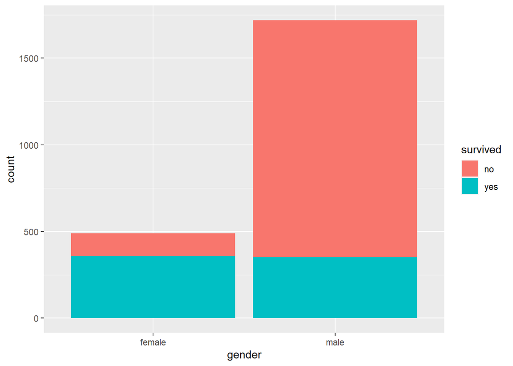

```r
# Visualizamos la relación entre las variables "sex" y "survival":
ggplot(data=totalData[1:filas,],aes(x=gender,fill=survived))+geom_bar()
```

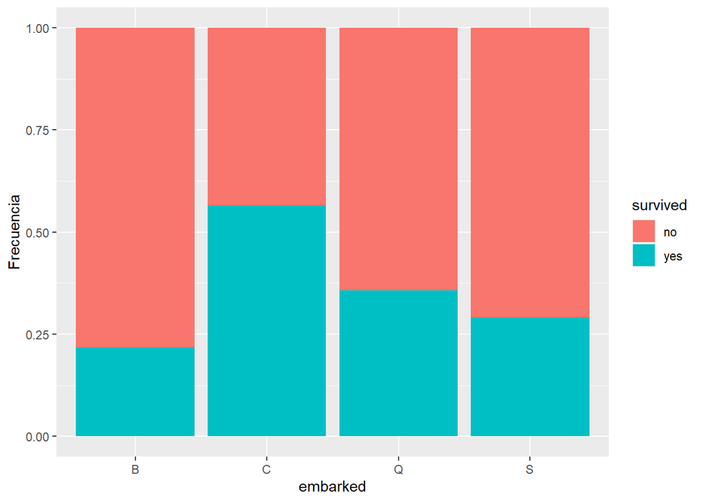

```r
# Otro punto de vista. Survival como función de Embarked:
ggplot(data = totalData[1:filas,],aes(x=embarked,fill=survived))+geom_bar(position="fill")+ylab("Frecuencia")
```

En la primera gráfica podemos observar fácilmente la cantidad de mujeres que viajaban respecto hombres y observar los que no sobrevivieron. Numéricamente el número de hombres y mujeres supervivientes es similar.

En la segunda gráfica de forma porcentual observamos los puertos de embarque y los porcentajes de supervivencia en función del puerto. Se podría trabajar el puerto C (Cherburgo) para ver de explicar la diferencia en los datos. Quizás porcentualmente embarcaron más mujeres o niños… O gente de primera clase?

Obtenemos ahora una matriz de porcentajes de frecuencia. Vemos, por ejemplo que la probabilidad de sobrevivir si se embarcó en “C” es de un 56.45%

```r
t<-table(totalData[1:filas,]$embarked,totalData[1:filas,]$survived)
for (i in 1:dim(t)[1]){
    t[i,]<-t[i,]/sum(t[i,])*100
}
t
```

```
##
##           no      yes
##   B 78.17259 21.82741
##   C 43.54244 56.45756
##   Q 64.22764 35.77236
##   S 70.85396 29.14604
```

Veamos ahora como en un mismo gráfico de frecuencias podemos trabajar con 3 variables: Embarked, Survived y Pclass.

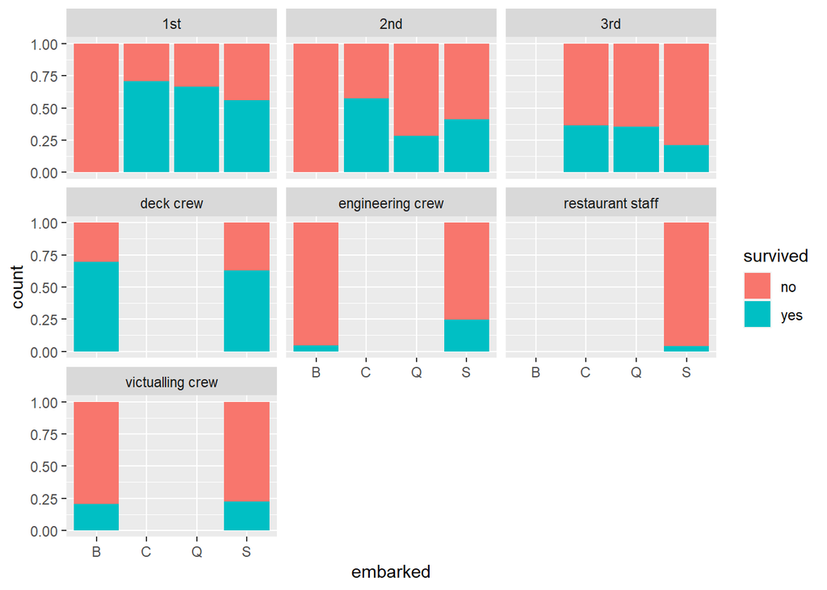

```r
# Ahora, podemos dividir el gráfico de Embarked por Pclass:
ggplot(data = totalData[1:filas,],aes(x=embarked,fill=survived))+geom_bar(position="fill")+facet_wrap(~class)
```

Aquí ya podemos extraer mucha información. Como propuesta de mejora se podría hacer un gráfico similar trabajando solo la clase. Habría que unificar toda la tripulación a una única categoría.

Comparemos ahora dos gráficos de frecuencias: Survived-SibSp y Survived-Parch

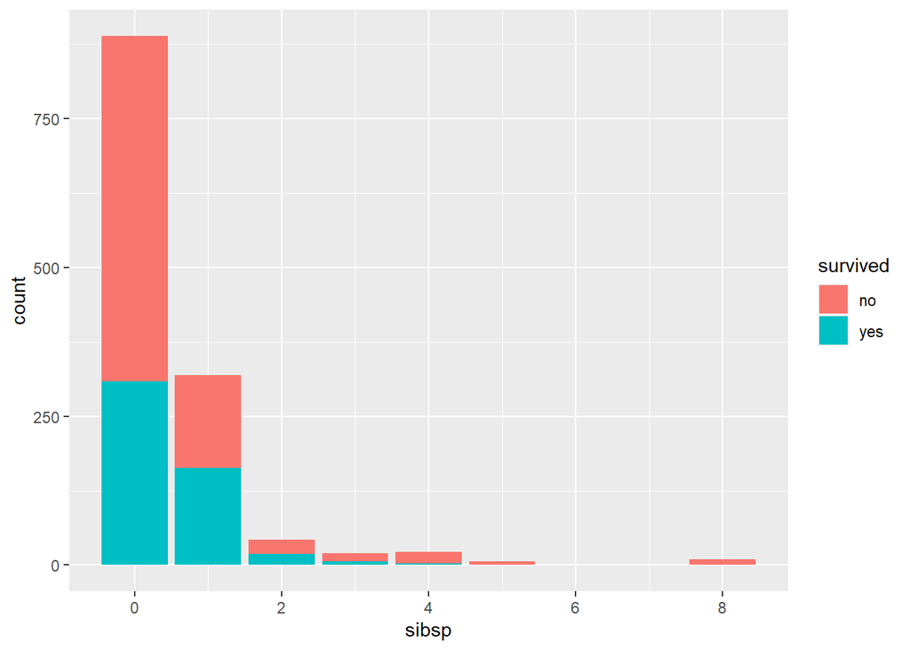

```r
# Survivial como función de SibSp y Parch
ggplot(data = totalData[1:filas,],aes(x=sibsp,fill=survived))+geom_bar()
```

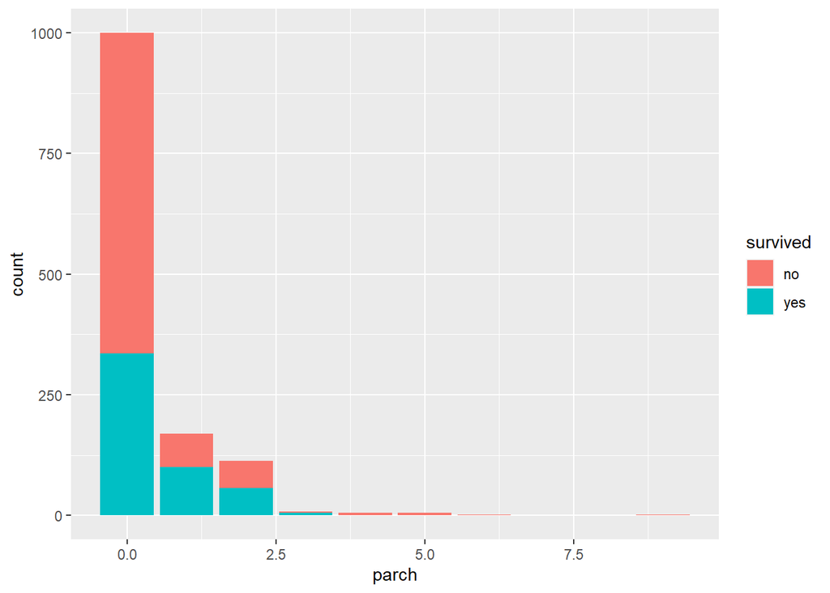

```r
ggplot(data = totalData[1:filas,],aes(x=parch,fill=survived))+geom_bar()
```

```r
# Vemos como las forma de estos dos gráficos es similar. Este hecho nos puede indicar presencia de correlaciones altas.
```

Veamos un ejemplo de construcción de una variable nueva: Tamaño de familia

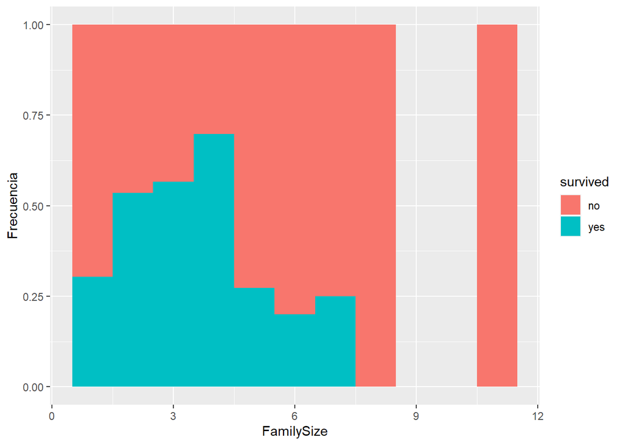

```r
# Construimos un atributo nuevo: family size.
totalData$FamilySize <- totalData$sibsp + totalData$parch +1;
totalData1<-totalData[1:filas,]
ggplot(data = totalData1[!is.na(totalData[1:filas,]$FamilySize),],aes(x=FamilySize,fill=survived))+geom_histogram(binwidth =1,position="fill")+ylab("Frecuencia")
```

Veamos ahora dos gráficos que nos compara los atributos Age y Survived.  
Observamos como el parámetro position=“fill” nos da la proporción acumulada de un atributo dentro de otro

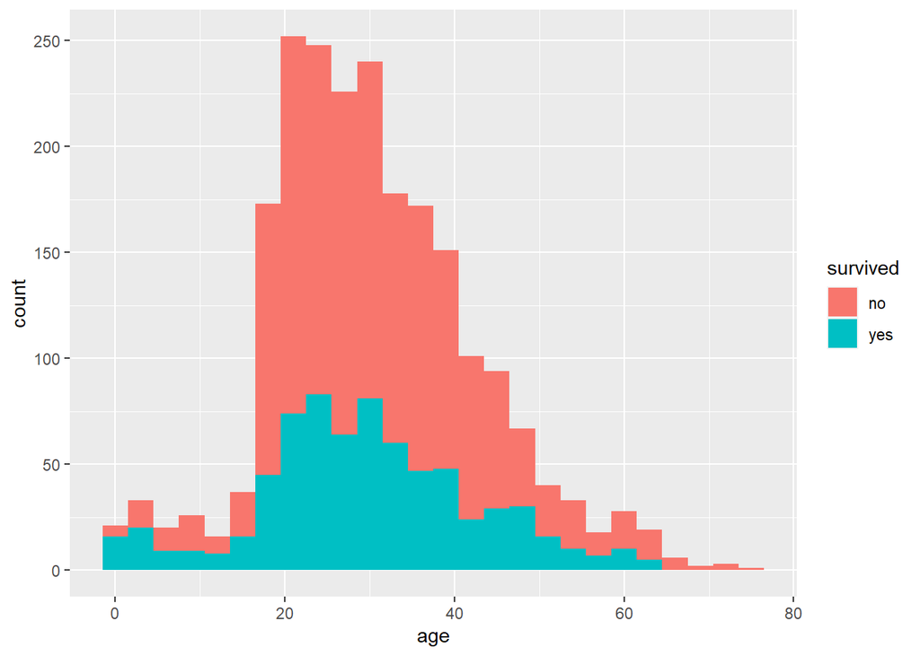

```r
# Survival como función de age:
ggplot(data = totalData1[!(is.na(totalData[1:filas,]$age)),],aes(x=age,fill=survived))+geom_histogram(binwidth =3)
```

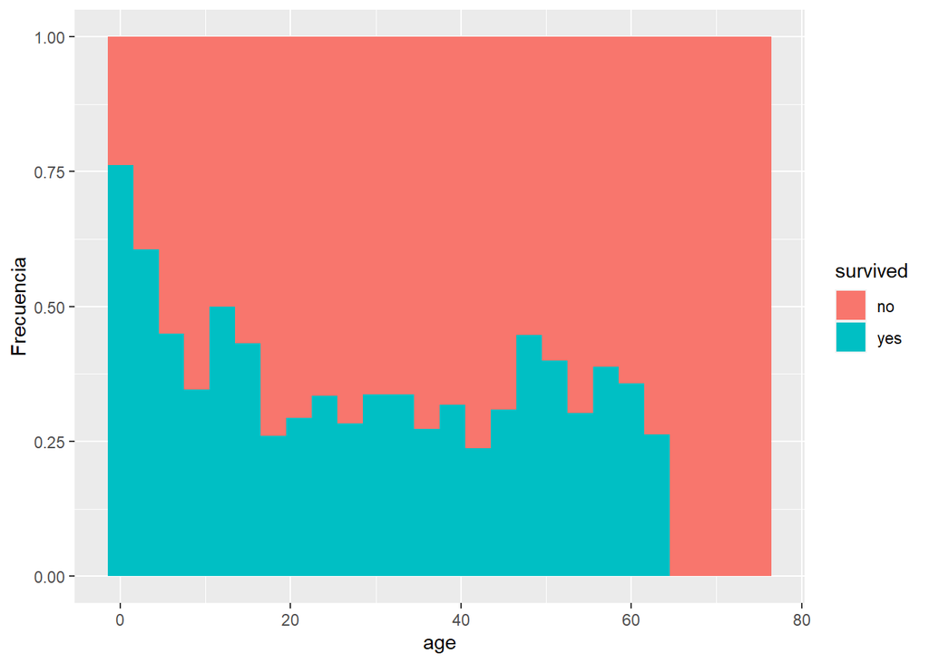

```r
ggplot(data = totalData1[!is.na(totalData[1:filas,]$age),],aes(x=age,fill=survived))+geom_histogram(binwidth = 3,position="fill")+ylab("Frecuencia")
```

# 4 Ejercicios

## 4.1 Ejercicio 1:

Estudia los tres casos siguientes y contesta, de forma razonada la pregunta que se realiza:

- Disponemos de un conjunto de variables referentes a vehículos, tales como la marca, modelo, año de matriculación, etc. También se dispone del precio al que se vendieron. Al poner a la venta a un nuevo vehículo, se dispone de las variables que lo describen, pero se desconoce el precio. ¿Qué tipo de algoritmo se debería aplicar para predecir de forma automática el precio?
- En un almacén de naranjas se tiene una máquina, que de forma automática obtiene un conjunto de variables de cada naranja, como su tamaño, acidez, grado maduración, etc. Si se desea estudiar las naranjas por tipos, según las variables obtenidas, ¿qué tipo de algoritmo es el más adecuado?
- Un servicio de música por internet dispone de los historiales de audición de sus clientes: Qué canciones y qué grupos eligen los clientes a lo largo del tiempo de sus escuchas. La empresa desea crear un sistema que proponga la siguiente canción y grupo en función de la canción que se ha escuchado antes. ¿Qué tipo de algoritmo es el más adecuado?

### 4.1.1 Respuesta 1:

#### 4.1.1.1 Primer caso

> Analizando el problema planteado obtenemos los datos esenciales para la elección del tipo de algoritmo: tenemos disponibles datos históricos, buscamos el atributo numérico “Precio”, de valor continuo, buscamos una predicción.

> La utilización del método estadístico de regresión predictivo nos permite determinar la relación de la variable salida, para valores continuos, en nuestro caso “Precio” con las variables de entrada tales como la marca, modelo, año de matriculación, etc. Básicamente queremos saber como la variable “Precio” se relaciona con una o mas variables de entrada y así poder predecir su comportamiento.

> Este método pertenece al tipo de aprendizaje supervisado, ya que se obtiene mediante el >entrenamiento usando el “histórico” disponible. Una vez obtenido el modelo este puede ser >usado para predecir el atributo “Precio” mediante las mismas variables descriptivas del >vehiculo.

> Recursos: pdf’s modulo 1 y 2 https://empresas.blogthinkbig.com/que-algoritmo-elegir-en-ml-aprendizaje/ Libro: DATA MINING concepts, Models, and Algorithms. (Mehmed Kantardzic).

#### 4.1.1.2 Segundo caso

> Analizando el problema planteado obtenemos los datos esenciales para la elección del tipo de algoritmo: conjunto de atributos no etiquetados, se busca una agrupación por tipo de naranjas, una vez agrupadas se procede al etiquetado, asumiendo que existe el conocimiento necesario para ello

> El método de aprendizaje mas adecuado sería de tipo no supervisado ya que nos permitiría analizar la relación o dependencias entre los atributos. Como no disponemos de grupos ya definidos, debemos usar un modelo de agregación por ejemplo: el método K-mean.

> Recursos: pdf’s modulo 1 y 2

#### 4.1.1.3 Tercer caso

> Analizando el problema planteado obtenemos los datos esenciales para la elección del tipo de algoritmo: tenemos disponibles datos históricos, se busca una predicción basándonos en una clasificación previa del historial.

> El método de aprendizaje mas adecuado sería de tipo supervisado ya que nos permitiría hacer una clasificación del historial de canciones disponibles. Por ejemplo una clasificación utilizando redes neuronales donde el nodo con mas peso pueda tomar la etiqueta ”Recomendar” o por el contrario “No recomendar”. Esta clasificación binaria que se puede entender como un predicción.

## 4.2 Ejercicio 2:

A partir del conjunto de datos disponible en el siguiente enlace http://archive.ics.uci.edu/ml/datasets/Adult , realiza un estudio tomando como propuesta inicial al que se ha realizado con el conjunto de datos “Titanic”. Amplia la propuesta generando nuevos indicadores o solucionando otros problemas expuestos en el módulo 2. Explica el proceso que has seguido, qué conocimiento obtienes de los datos, qué objetivo te has fijado y detalla los pasos, técnicas usadas y los problemas resueltos.

Nota: Si lo deseas puedes utilizar otro conjunto de datos propio o de algún repositorio open data siempre que sea similar en diversidad de tipos de variables al propuesto.

### 4.2.1 Respuesta 2:

```r
# Cargamos el juego de datos
datosAdult <- read.csv('http://archive.ics.uci.edu/ml/machine-learning-databases/adult/adult.data',stringsAsFactors = FALSE, header = FALSE)

# Nombres de los atributos
names(datosAdult) <- c("age","workclass","fnlwgt","education","education-num","marital-status","occupation","relationship","race","sex","capital-gain","capital-loss","hour-per-week","native-country","income")
```

#### 4.2.1.1 Procesos de limpieza y falta del conjunto de datos:

Echamos un vistazo a los tipos de datos y su definición.

```r
# Redacta aquí el código R para el estudio del juego de datos Adult
#Mostramos la estructura de la structura de los datos
str(datosAdult)
```

```
## 'data.frame':    32561 obs. of  15 variables:
##  $ age           : int  39 50 38 53 28 37 49 52 31 42 ...
##  $ workclass     : chr  " State-gov" " Self-emp-not-inc" " Private" " Private" ...
##  $ fnlwgt        : int  77516 83311 215646 234721 338409 284582 160187 209642 45781 159449 ...
##  $ education     : chr  " Bachelors" " Bachelors" " HS-grad" " 11th" ...
##  $ education-num : int  13 13 9 7 13 14 5 9 14 13 ...
##  $ marital-status: chr  " Never-married" " Married-civ-spouse" " Divorced" " Married-civ-spouse" ...
##  $ occupation    : chr  " Adm-clerical" " Exec-managerial" " Handlers-cleaners" " Handlers-cleaners" ...
##  $ relationship  : chr  " Not-in-family" " Husband" " Not-in-family" " Husband" ...
##  $ race          : chr  " White" " White" " White" " Black" ...
##  $ sex           : chr  " Male" " Male" " Male" " Male" ...
##  $ capital-gain  : int  2174 0 0 0 0 0 0 0 14084 5178 ...
##  $ capital-loss  : int  0 0 0 0 0 0 0 0 0 0 ...
##  $ hour-per-week : int  40 13 40 40 40 40 16 45 50 40 ...
##  $ native-country: chr  " United-States" " United-States" " United-States" " United-States" ...
##  $ income        : chr  " <=50K" " <=50K" " <=50K" " <=50K" ...
```

Descripción de las variables contenidas en el fichero:

Listing of attributes:

- 1. age: continuous.
- 2. workclass: Private, Self-emp-not-inc, Self-emp-inc, Federal-gov, Local-gov, State-gov, Without-pay, Never-worked.
- 3. fnlwgt: continuous.
- 4. education: Bachelors, Some-college, 11th, HS-grad, Prof-school, Assoc-acdm, Assoc-voc, 9th, 7th-8th, 12th, Masters, 1st-4th, 10th, Doctorate, 5th-6th, Preschool.
- 5. education-num: continuous.
- 6. marital-status: Married-civ-spouse, Divorced, Never-married, Separated, Widowed, Married-spouse-absent, Married-AF-spouse.
- 7. occupation: Tech-support, Craft-repair, Other-service, Sales, Exec-managerial, Prof-specialty, Handlers-cleaners, Machine-op-inspct, Adm-clerical, Farming-fishing, Transport-moving, Priv-house-serv, Protective-serv, Armed-Forces.
- 8. relationship: Wife, Own-child, Husband, Not-in-family, Other-relative, Unmarried.
- 9. race: White, Asian-Pac-Islander, Amer-Indian-Eskimo, Other, Black.
- 10.sex: Female, Male.
- 11.capital-gain: continuous.
- 12.capital-loss: continuous.
- 13.hours-per-week: continuous.
- 14.native-country: United-States, Cambodia, England, Puerto-Rico, Canada, Germany, Outlying-US(Guam-USVI-etc), India, Japan, Greece, South, China, Cuba, Iran, Honduras, Philippines, Italy, Poland, Jamaica, Vietnam, Mexico, Portugal, Ireland, France, Dominican-Republic, Laos, Ecuador, Taiwan, Haiti, Columbia, Hungary, Guatemala, Nicaragua, Scotland, Thailand, Yugoslavia, El-Salvador, Trinadad&Tobago, Peru, Hong, Holand-Netherlands.
- 15.income

```r
#Estadíssticas básicas
summary(datosAdult)
```

```
##       age         workclass             fnlwgt         education
##  Min.   :17.00   Length:32561       Min.   :  12285   Length:32561
##  1st Qu.:28.00   Class :character   1st Qu.: 117827   Class :character
##  Median :37.00   Mode  :character   Median : 178356   Mode  :character
##  Mean   :38.58                      Mean   : 189778
##  3rd Qu.:48.00                      3rd Qu.: 237051
##  Max.   :90.00                      Max.   :1484705
##  education-num   marital-status      occupation        relationship
##  Min.   : 1.00   Length:32561       Length:32561       Length:32561
##  1st Qu.: 9.00   Class :character   Class :character   Class :character
##  Median :10.00   Mode  :character   Mode  :character   Mode  :character
##  Mean   :10.08
##  3rd Qu.:12.00
##  Max.   :16.00
##      race               sex             capital-gain    capital-loss
##  Length:32561       Length:32561       Min.   :    0   Min.   :   0.0
##  Class :character   Class :character   1st Qu.:    0   1st Qu.:   0.0
##  Mode  :character   Mode  :character   Median :    0   Median :   0.0
##                                        Mean   : 1078   Mean   :  87.3
##                                        3rd Qu.:    0   3rd Qu.:   0.0
##                                        Max.   :99999   Max.   :4356.0
##  hour-per-week   native-country        income
##  Min.   : 1.00   Length:32561       Length:32561
##  1st Qu.:40.00   Class :character   Class :character
##  Median :40.00   Mode  :character   Mode  :character
##  Mean   :40.44
##  3rd Qu.:45.00
##  Max.   :99.00
```

Limpiamos las etiquetas de espacios en blanco

```r
#Importamos la libreria para trabajar con cadena de carácteres
library(stringr)

#Comprobamos si hay espacios en blanco
str_detect(datosAdult," ")
```

```
##  [1] TRUE TRUE TRUE TRUE TRUE TRUE TRUE TRUE TRUE TRUE TRUE TRUE TRUE TRUE TRUE
```

```r
#Eliminamos los espacios en blanco mediante el reemplazo
datosAdult$workclass <- str_replace_all(datosAdult$workclass," ","")
datosAdult$education <- str_replace_all(datosAdult$education," ","")
datosAdult$`marital-status` <- str_replace_all(datosAdult$`marital-status`," ","")
datosAdult$occupation <- str_replace_all(datosAdult$occupation," ","")
datosAdult$relationship <- str_replace_all(datosAdult$relationship," ","")
datosAdult$race <- str_replace_all(datosAdult$race," ","")
datosAdult$sex <- str_replace_all(datosAdult$sex," ","")
datosAdult$`native-country` <- str_replace_all(datosAdult$`native-country`," ","")
datosAdult$income <- str_replace_all(datosAdult$income," ","")

# Después de los cambios, analizamos la nueva estructura del conjunto de datos
str(datosAdult)
```

```
## 'data.frame':    32561 obs. of  15 variables:
##  $ age           : int  39 50 38 53 28 37 49 52 31 42 ...
##  $ workclass     : chr  "State-gov" "Self-emp-not-inc" "Private" "Private" ...
##  $ fnlwgt        : int  77516 83311 215646 234721 338409 284582 160187 209642 45781 159449 ...
##  $ education     : chr  "Bachelors" "Bachelors" "HS-grad" "11th" ...
##  $ education-num : int  13 13 9 7 13 14 5 9 14 13 ...
##  $ marital-status: chr  "Never-married" "Married-civ-spouse" "Divorced" "Married-civ-spouse" ...
##  $ occupation    : chr  "Adm-clerical" "Exec-managerial" "Handlers-cleaners" "Handlers-cleaners" ...
##  $ relationship  : chr  "Not-in-family" "Husband" "Not-in-family" "Husband" ...
##  $ race          : chr  "White" "White" "White" "Black" ...
##  $ sex           : chr  "Male" "Male" "Male" "Male" ...
##  $ capital-gain  : int  2174 0 0 0 0 0 0 0 14084 5178 ...
##  $ capital-loss  : int  0 0 0 0 0 0 0 0 0 0 ...
##  $ hour-per-week : int  40 13 40 40 40 40 16 45 50 40 ...
##  $ native-country: chr  "United-States" "United-States" "United-States" "United-States" ...
##  $ income        : chr  "<=50K" "<=50K" "<=50K" "<=50K" ...
```

Comprobamos que no existen NA (NULL) valores para los atributos numericos:

```r
# Estadísticas de valores vacíos
colSums(is.na(datosAdult))
```

```
##            age      workclass         fnlwgt      education  education-num
##              0              0              0              0              0
## marital-status     occupation   relationship           race            sex
##              0              0              0              0              0
##   capital-gain   capital-loss  hour-per-week native-country         income
##              0              0              0              0              0
```

Comprobamos que los no existen valores no etiquedaos:

```r
# Mostramos valores en blanco
colSums(datosAdult=="")
```

```
##            age      workclass         fnlwgt      education  education-num
##              0              0              0              0              0
## marital-status     occupation   relationship           race            sex
##              0              0              0              0              0
##   capital-gain   capital-loss  hour-per-week native-country         income
##              0              0              0              0              0
```

Vemos si hay atributos categóricos que tienen valores desconocidos.

```r
# Mostramos los atributos que contienen el valor ?
colSums(datosAdult=="?")
```

```
##            age      workclass         fnlwgt      education  education-num
##              0           1836              0              0              0
## marital-status     occupation   relationship           race            sex
##              0           1843              0              0              0
##   capital-gain   capital-loss  hour-per-week native-country         income
##              0              0              0            583              0
```

```r
# Mostramos los totales
table(datosAdult$workclass)
```

```
##
##                ?      Federal-gov        Local-gov     Never-worked
##             1836              960             2093                7
##          Private     Self-emp-inc Self-emp-not-inc        State-gov
##            22696             1116             2541             1298
##      Without-pay
##               14
```

```r
table(datosAdult$occupation)
```

```
##
##                 ?      Adm-clerical      Armed-Forces      Craft-repair
##              1843              3770                 9              4099
##   Exec-managerial   Farming-fishing Handlers-cleaners Machine-op-inspct
##              4066               994              1370              2002
##     Other-service   Priv-house-serv    Prof-specialty   Protective-serv
##              3295               149              4140               649
##             Sales      Tech-support  Transport-moving
##              3650               928              1597
```

```r
table(datosAdult$education)
```

```
##
##         10th         11th         12th      1st-4th      5th-6th      7th-8th
##          933         1175          433          168          333          646
##          9th   Assoc-acdm    Assoc-voc    Bachelors    Doctorate      HS-grad
##          514         1067         1382         5355          413        10501
##      Masters    Preschool  Prof-school Some-college
##         1723           51          576         7291
```

```r
#
```

```r
datosAdult$workclass <- as.factor(gsub("[?]", NA, datosAdult$workclass))
datosAdult$occupation <- as.factor(gsub("[?]", NA, datosAdult$occupation))
datosAdult$education <- as.factor(gsub("[?]", NA, datosAdult$education))
```

Creamos un nueva clase para el atributo workclass que podría facilitar el analisis posterior. Las nuevas tegorías las guardo en “datosAdult_wk” para poder analizarlo por separado del conjuto de datos original. Los nuevos grupos englobarían tabajos en el sector público, sector privado, autonomos y otros.

```r
#Creamos una copia de los datos y agrupamos
datosAdult_wk <- datosAdult

# Creamos un grupo para autónomos
datosAdult_wk$workclass <- gsub('^Self-emp-inc', 'Freelance', datosAdult_wk$workclass)
datosAdult_wk$workclass <- gsub('^Self-emp-not-inc', 'Freelance', datosAdult_wk$workclass)

# Creamos un grupo para trabajos en el sector público
datosAdult_wk$workclass <- gsub('^State-gov', 'Public', datosAdult_wk$workclass)
datosAdult_wk$workclass <- gsub('^Local-gov', 'Public', datosAdult_wk$workclass)
datosAdult_wk$workclass <- gsub('^Federal-gov', 'Public', datosAdult_wk$workclass)

# Creamos un grupo para desempleados u oros
datosAdult_wk$workclass <- gsub('^Never-worked', 'Unemployed/Other', datosAdult_wk$workclass)
datosAdult_wk$workclass <- gsub('^Without-pay', 'Unemployed/Other', datosAdult_wk$workclass)

# Mostramos los grupos creados
table(datosAdult_wk$workclass)
```

```
##
##        Freelance          Private           Public Unemployed/Other
##             3657            22696             4351               21
```

Repetimos el proceso para el atributo “education” agrupandolo en tres clases; Educación primaria, media y superior guardandolo el resultado en el conjuto de datos “datosAdult_wk”.

```r
#Elementary education
datosAdult_wk$education <- gsub('^1st-4th', 'Elementary', datosAdult_wk$education)
datosAdult_wk$education <- gsub('^5th-6th', 'Elementary', datosAdult_wk$education)
datosAdult_wk$education <- gsub('^7th-8th', 'Elementary', datosAdult_wk$education)
datosAdult_wk$education <- gsub('^Preschool', 'Elementary', datosAdult_wk$education)

#Secondary education
datosAdult_wk$education <- gsub('^9th', 'Secondary', datosAdult_wk$education)
datosAdult_wk$education <- gsub('^10th', 'Secondary', datosAdult_wk$education)
datosAdult_wk$education <- gsub('^11th', 'Secondary', datosAdult_wk$education)
datosAdult_wk$education <- gsub('^12th', 'Secondary', datosAdult_wk$education)
datosAdult_wk$education <- gsub('^HS-grad', 'Secondary', datosAdult_wk$education)
datosAdult_wk$education <- gsub('^Some-college', 'Higher', datosAdult_wk$education)

# Higher education
datosAdult_wk$education <- gsub('^Prof-school', 'Higher', datosAdult_wk$education)
datosAdult_wk$education <- gsub('^Assoc-acdm', 'Higher', datosAdult_wk$education)
datosAdult_wk$education <- gsub('^Assoc-voc', 'Higher', datosAdult_wk$education)
datosAdult_wk$education <- gsub('^Prof-school', 'Higher', datosAdult_wk$education)
datosAdult_wk$education <- gsub('^Doctorate', 'Higher', datosAdult_wk$education)
datosAdult_wk$education <- gsub('^Masters', 'Higher', datosAdult_wk$education)
datosAdult_wk$education <- gsub('^Bachelors', 'Higher', datosAdult_wk$education)

# Mostramos los grupos creados
table(datosAdult_wk$education)
```

```
##
## Elementary     Higher  Secondary
##       1198      17807      13556
```

Analizamos una posible discretización para variables con clases limitadas.

```r
# Mostramos los posibles atributos a discretizar
apply(datosAdult, 2, function(x) length(unique(x)))
```

```
##            age      workclass         fnlwgt      education  education-num
##             73              9          21648             16             16
## marital-status     occupation   relationship           race            sex
##              7             15              6              5              2
##   capital-gain   capital-loss  hour-per-week native-country         income
##            119             92             94             42              2
```

```r
# Discretización de las variables
cols<-c("income","sex","race","relationship")
for (i in cols){
  datosAdult[,i] <- as.factor(datosAdult[,i])
}

# Después de los cambios, analizamos la nueva estructura del conjunto de datos
str(datosAdult)
```

```
## 'data.frame':    32561 obs. of  15 variables:
##  $ age           : int  39 50 38 53 28 37 49 52 31 42 ...
##  $ workclass     : Factor w/ 8 levels "Federal-gov",..: 7 6 4 4 4 4 4 6 4 4 ...
##  $ fnlwgt        : int  77516 83311 215646 234721 338409 284582 160187 209642 45781 159449 ...
##  $ education     : Factor w/ 16 levels "10th","11th",..: 10 10 12 2 10 13 7 12 13 10 ...
##  $ education-num : int  13 13 9 7 13 14 5 9 14 13 ...
##  $ marital-status: chr  "Never-married" "Married-civ-spouse" "Divorced" "Married-civ-spouse" ...
##  $ occupation    : Factor w/ 14 levels "Adm-clerical",..: 1 4 6 6 10 4 8 4 10 4 ...
##  $ relationship  : Factor w/ 6 levels "Husband","Not-in-family",..: 2 1 2 1 6 6 2 1 2 1 ...
##  $ race          : Factor w/ 5 levels "Amer-Indian-Eskimo",..: 5 5 5 3 3 5 3 5 5 5 ...
##  $ sex           : Factor w/ 2 levels "Female","Male": 2 2 2 2 1 1 1 2 1 2 ...
##  $ capital-gain  : int  2174 0 0 0 0 0 0 0 14084 5178 ...
##  $ capital-loss  : int  0 0 0 0 0 0 0 0 0 0 ...
##  $ hour-per-week : int  40 13 40 40 40 40 16 45 50 40 ...
##  $ native-country: chr  "United-States" "United-States" "United-States" "United-States" ...
##  $ income        : Factor w/ 2 levels "<=50K",">50K": 1 1 1 1 1 1 1 2 2 2 ...
```

Como vamos a trabajar la variable “income” sobre la gente que trabaja filtramos la población que no esta activa y comprobamos que el filtro se ha aplicado correctamente. Como peculiaridad vemos que el trabajo freelance tiene una distribucion con muchos más picos que el resto.

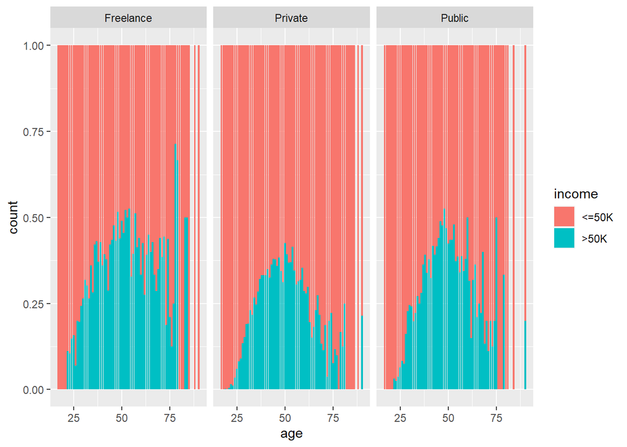

```r
# Filtro la poblacion que no esta trabajando
datosAdult <- datosAdult_wk %>% filter(workclass == "Public" | workclass == "Private" | workclass == "Freelance")

ggplot(datosAdult,aes(x=age,fill=income))+geom_bar(position="fill")+facet_wrap(~workclass)
```

#### 4.2.1.2 Procesos de análisis del conjunto de datos

Me gustaría centrarme en las relaciones del conjunto de datos con la variable “income” realizando un análisis con caracter descriptivo y exploratorio.

La primera pregunta que me viene a la cabeza es la brecha salaraial entre los dos grupos de la clase income. Hay una diferencia salarial entre hombres y mujeres y si es así se podría argumentar con los datos obtenidos?

En relación con el grupo >50 que es donde se ve una diferencia sustancial: Habrá mas hombres que mujeres con estudios superiores? Habrá más hombres que mujeres en edades donde el salario sea superior? Harán más horas por semana los hombres que las mujeres?

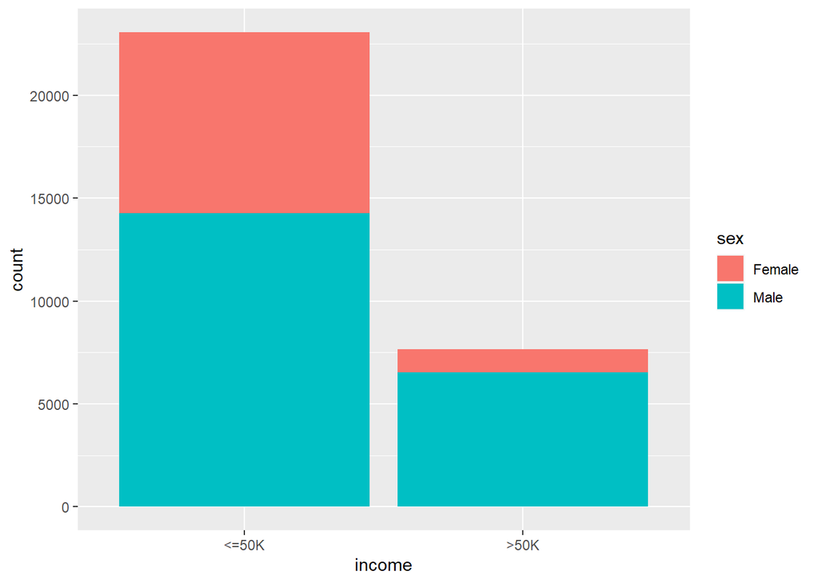

```r
# Relacion de la variable income y genero.
ggplot( datosAdult, aes(x=income, fill= sex))+geom_bar()
```

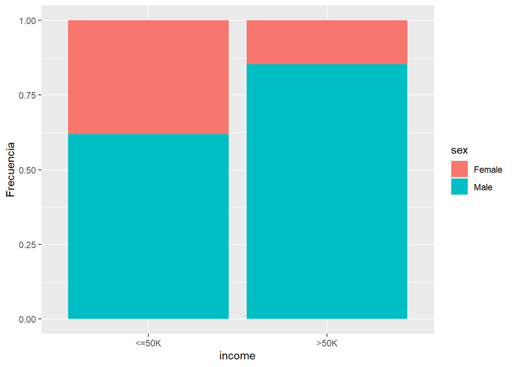

```r
ggplot(datosAdult, aes(x=income, fill=sex))+geom_bar(position="fill")+ylab("Frecuencia")
```

La gráfica refleja que por debajo de los 50k hay más hombres que mujeres pero por encima de los >50k se ve claramente que la proporcion de hombre es muchisimo mayor. La diferencia puede ser entendida ya que hay más hombres que mujeres en el conjunto de datos, pero aún así la grafica muestra que los dos grupos, >50K y <50K, no están igualmente distribuidos.

Veamos las proporciones para estas dos variables:

```r
# Estadistica descriptiva
table(datosAdult$sex)
```

```
##
## Female   Male
##   9925  20779
```

```r
prop.table(table(datosAdult$sex))
```

```
##
##    Female      Male
## 0.3232478 0.6767522
```

```r
prop.table(table(datosAdult$income))
```

```
##
##     <=50K      >50K
## 0.7508468 0.2491532
```

```r
prop.table(table(datosAdult$sex, datosAdult$income))
```

```
##
##               <=50K       >50K
##   Female 0.28654247 0.03670532
##   Male   0.46430433 0.21244789
```

Observamos un 67,7% de hombres respecto a un 32% de mujeres. El primer grupo, el que tiene un income inferior al 50K tiene una relacion aproximadamente proporcional al numero total de mujeres y hombre, siendo las mujeres ligerametne superior.

Pero por qué aumenta sustancialmente la diferencia por encima de los 50k? Quiza la mayoria de mujeres están posicionadas en los extremos de la distribucion y entonces pueden ser muy jóvenes o demasiado mayores para recibir un “income” superior a 50K?

Veamos las distribucion del atributo edad:

```r
# Estadistica descriptiva.
summary(datosAdult$age)
```

```
##    Min. 1st Qu.  Median    Mean 3rd Qu.    Max.
##   17.00   28.00   37.00   38.44   47.00   90.00
```

Observando los percentiles, el max y el min, podemos hacernos una primera idea de la forma de la distribución. Es una distribucion más prolongada por la cola derecha “right skewed distribution” (viendo la posicion de la media con los max y min) y abrupta en la parte izquierda. La distribucion es la esperada y refleja la poblacion en activo durante todo el tiempo laboral. La parte izquierda podría reflejar la entrada al mercado laboral y entre 28 años 47 años estaría el 50% de la poblacion en activo. Recuerda que trabajamos con poblacion en activo ya que hemos aplicado los filtro previamente a la gente desempleada.

Veamos las distribucion del atributo genero respecto a la edad:

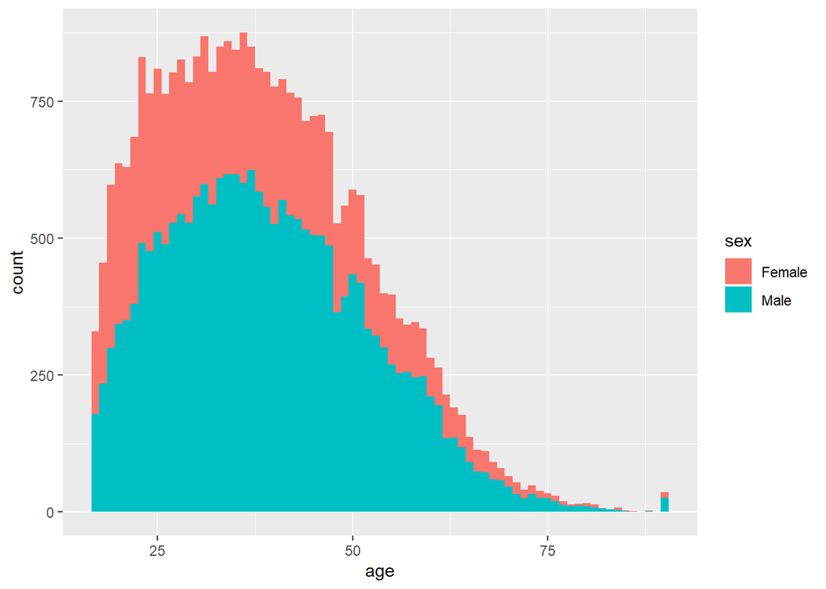

```r
# Sex como función del atributo edad.
ggplot(datosAdult ,aes(x=age, fill= sex)) +geom_histogram(binwidth =1)
```

```r
#Creamos diferentes grupos para poder nalizarlos por separado.
Male <- datosAdult %>% filter(sex == "Male")
Female <- datosAdult %>% filter(sex == "Female")

# Mostramos los percentiles
summary(Male$age)
```

```
##    Min. 1st Qu.  Median    Mean 3rd Qu.    Max.
##   17.00   29.00   38.00   39.19   48.00   90.00
```

```r
summary(Female$age)
```

```
##    Min. 1st Qu.  Median    Mean 3rd Qu.    Max.
##   17.00   26.00   35.00   36.87   46.00   90.00
```

La graficá refleja que la distribución para los hombres está desplazada a la derecha por lo que hay más pablacion con mayor edad respecto al de las mujeres. Quizá se deba a prerfiles de trabajadores más seniors y con más experiencia donde el salario sea ligeramente superior?

Veamos en que rango de edades se distribuye el atributo para los dos grupos income >=50 y >50:

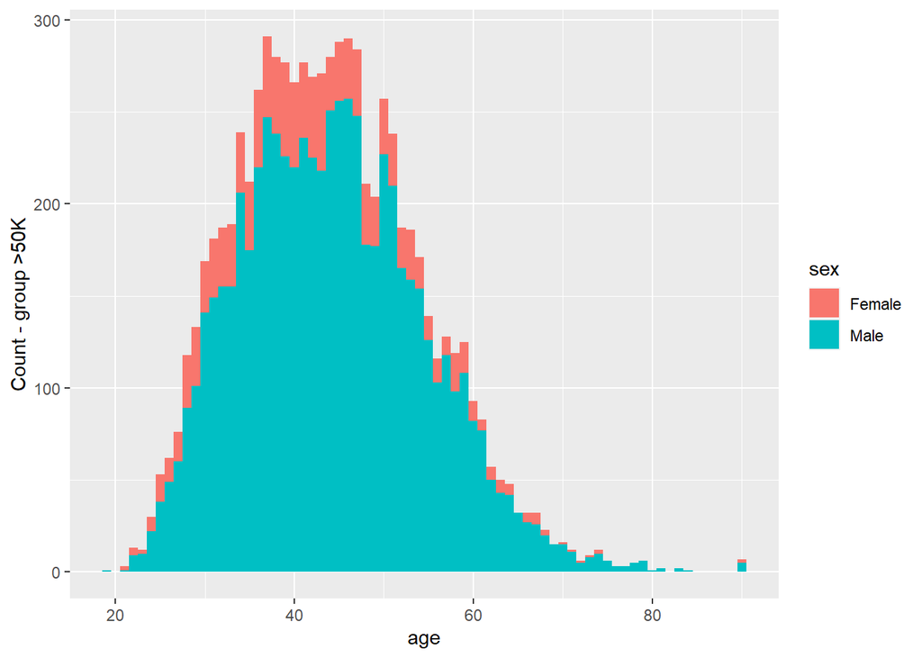

```r
#Creamos diferentes grupos para poder nalizarlos por separado.

# Filtramos por income
More50 <- datosAdult %>% filter(income == ">50K")
Less50 <- datosAdult %>% filter(income == "<=50K")

# Filramos los datos del conjunto por genero Female y income
FemaleMore50 <- datosAdult %>% filter(sex == "Female", income == ">50K")
FemaleLess50 <- datosAdult %>% filter(sex == "Female", income == "<=50K")

# Filramos los datos del conjunto por genero
MaleMore50 <- datosAdult %>% filter(sex == "Male", income == ">50K")
MaleLess50 <- datosAdult %>% filter(sex == "Male", income == "<=50K")

# Filtramos por income
More50 <- datosAdult %>% filter(income == ">50K")
Less50 <- datosAdult %>% filter(income == "<=50K")

# Income como función del atributo age.
ggplot( More50 ,aes(x=age, fill= sex)) + geom_histogram(binwidth =1) + ylab("Count - group >50K")
```

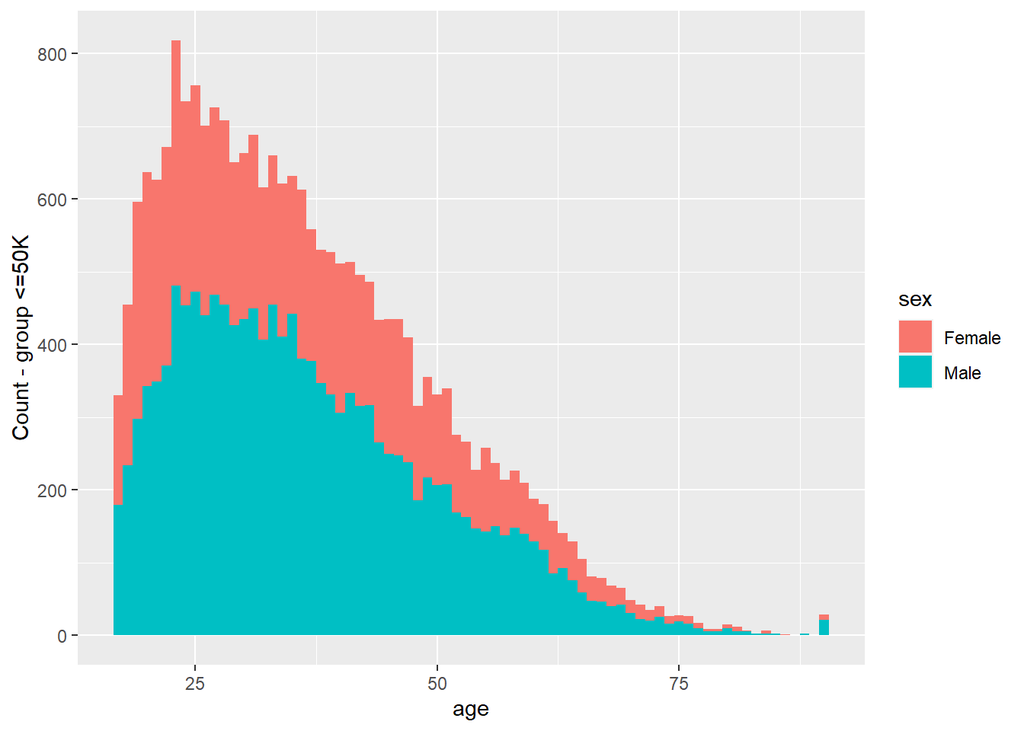

```r
ggplot( Less50 ,aes(x=age, fill= sex)) + geom_histogram(binwidth =1) + ylab("Count - group <=50K")
```

Lo vemos ahora dede otro punto de vista, mediante la funcion acumulativa para el genero male y female:

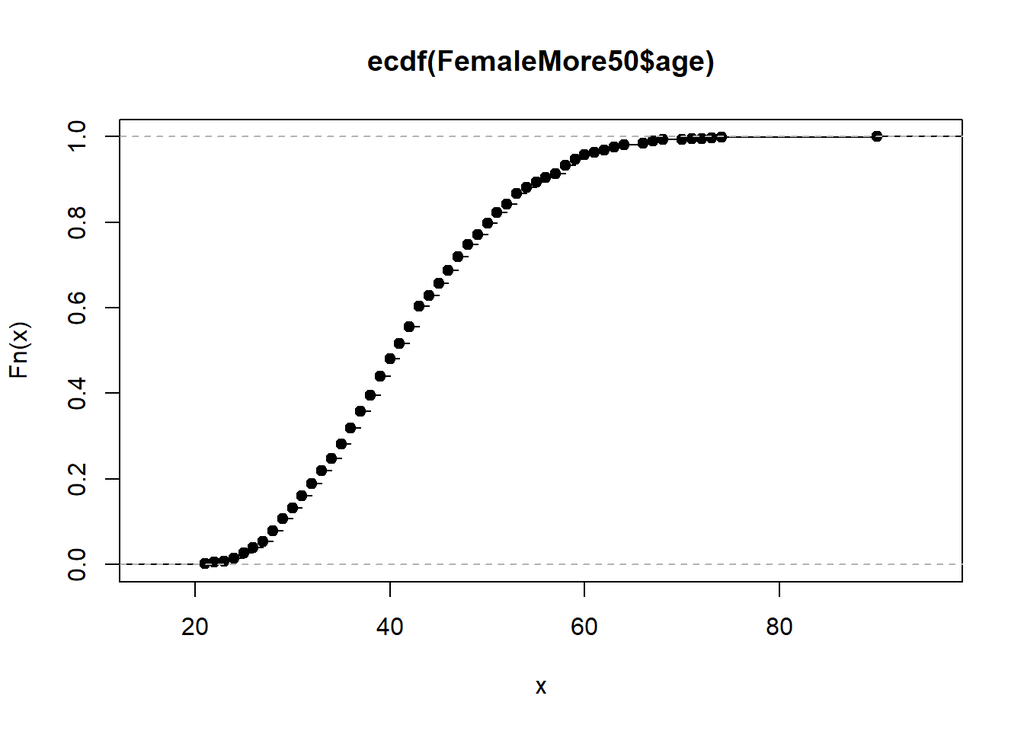

```r
# Ejecutamos la funcion distributiva dividida por genero
P1 = ecdf(FemaleMore50$age)
P2 = ecdf(MaleMore50$age)
P3 = ecdf(FemaleLess50$age)
P4 = ecdf(MaleLess50$age)


# La mostramos por pantalla mediante la funcion plot
plot(P1)
```

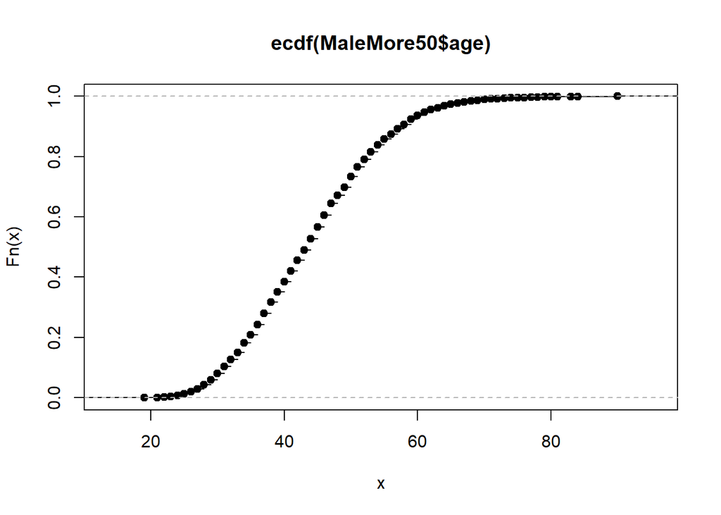

```r
plot(P2)
```

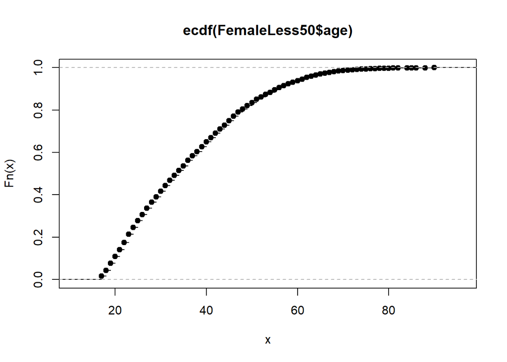

```r
plot(P3)
```

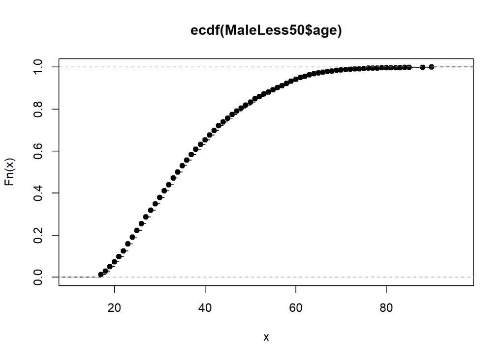

```r
plot(P4)
```

Observamos que las funciones están posicionadas en edades diferentes para el grupo >50 y muy parecidas en <50.

```r
# Mostramos los percentiles por genero y menos de 50k
summary(FemaleLess50$age)
```

```
##    Min. 1st Qu.  Median    Mean 3rd Qu.    Max.
##   17.00   25.00   34.00   36.22   45.00   90.00
```

```r
summary(MaleLess50$age)
```

```
##    Min. 1st Qu.  Median    Mean 3rd Qu.    Max.
##   17.00   26.00   34.00   36.85   45.00   90.00
```

```r
# Mostramos los percentiles por genero y más de 50k
summary(FemaleMore50$age)
```

```
##    Min. 1st Qu.  Median    Mean 3rd Qu.    Max.
##   21.00   35.00   41.00   42.01   49.00   90.00
```

```r
summary(MaleMore50$age)
```

```
##    Min. 1st Qu.  Median    Mean 3rd Qu.    Max.
##    19.0    37.0    44.0    44.3    51.0    90.0
```

Veamos si la educacion influye en salario:

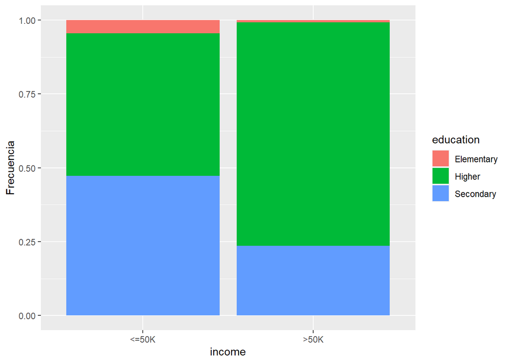

```r
# Visualizamos el nivel de educacion en función de la variable income
ggplot( datosAdult, aes(x=income, fill=education )) + geom_bar(position="fill") + ylab("Frecuencia")
```

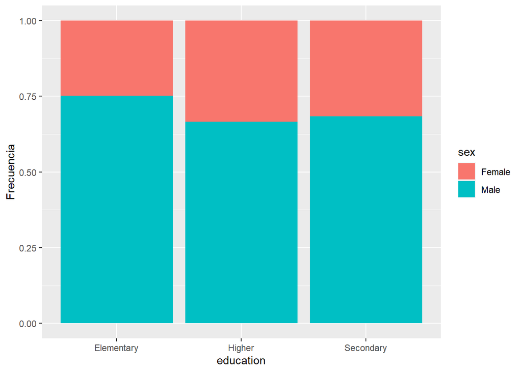

```r
# Visualizamos el nivel de educacion en función del genero
ggplot( datosAdult, aes(x=education, fill=sex )) + geom_bar(position="fill") + ylab("Frecuencia")
```

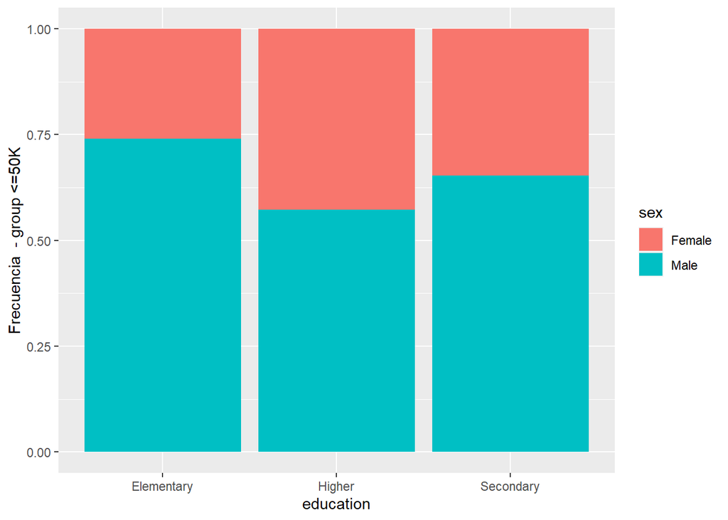

```r
# Visualizamos el genero en funcion de la educacion para el variable <=50
Less50 <- datosAdult %>% filter(income == "<=50K")
ggplot( Less50, aes(x=education, fill=sex )) + geom_bar(position="fill") + ylab("Frecuencia  - group <=50K")
```

[figure not shown]

```r
# Visualizamos el genero en funcion de la educacion para el variable >=50
More50 <- datosAdult %>% filter(income == ">50K")
ggplot( More50, aes(x=education, fill=sex)) + geom_bar(position="fill") + ylab("Frecuencia   - group <=50K")
```

Si comparamos el histograma dos y tres vemos que existe un patrón más o menos proporional entre el total (histograma 2) y el grupo con un income por debajo de 50K, siendo las mujeres ligeramente superiores en los tres grupos de educación del hisograna tres.

El último histograma refleja un aumento bastante sustancial de hombres respecto a mujeres.

Veamos si las horas por semana influyen en el salario:

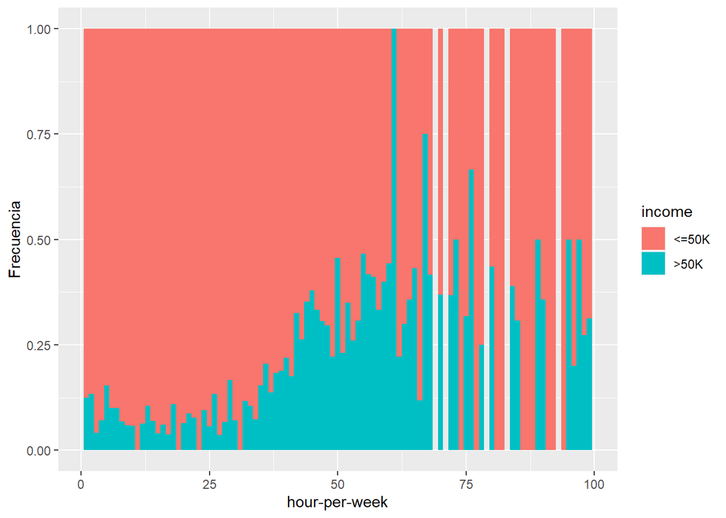

```r
#Visualizamos income en funcion de las horas
ggplot( data=subset(datosAdult, !is.na(`hour-per-week`)), aes(x=`hour-per-week`, fill=income )) + geom_histogram(binwidth =1, position="fill") + ylab("Frecuencia")
```

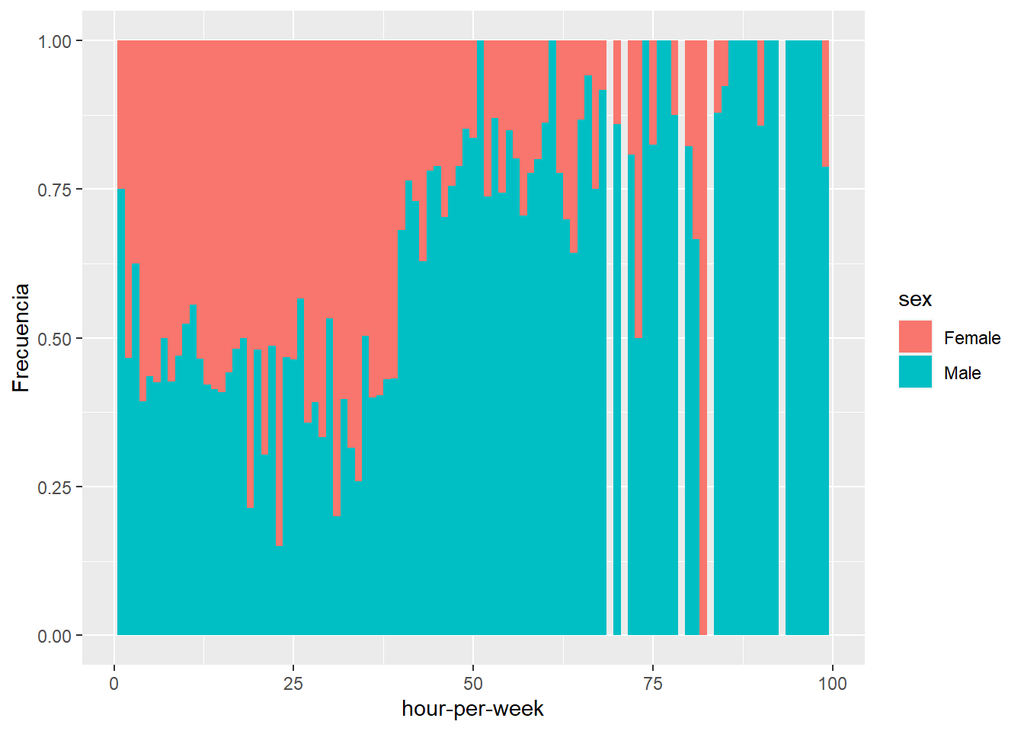

```r
#Visualizamos el genero en funcion de las horas
ggplot( data=subset(datosAdult, !is.na(`hour-per-week`)), aes(x=`hour-per-week`, fill=sex )) + geom_histogram(binwidth =1, position="fill") + ylab("Frecuencia")
```

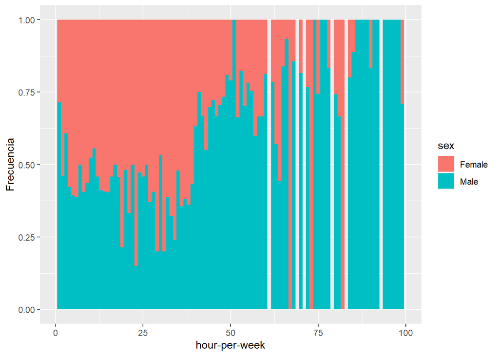

```r
#Visualizamos ahora para los grupos <=50 y >50
ggplot( data=subset( Less50, !is.na(`hour-per-week`)), aes(x=`hour-per-week`, fill=sex )) + geom_histogram(binwidth =1,position="fill")+ylab("Frecuencia")
```

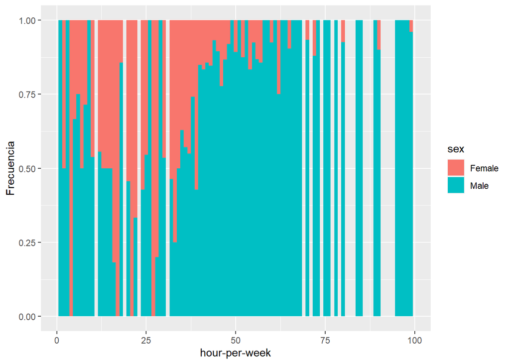

```r
ggplot( data=subset( More50, !is.na(`hour-per-week`)), aes(x=`hour-per-week`, fill=sex )) + geom_histogram(binwidth =1,position="fill")+ylab("Frecuencia")
```

Si comparamos el histograma dos y tres vemos un patrón más o menos proporional en relación entre hombre y mujeres para el grupo <50.

El último histograma refleja un aumento bastante sustancia de hombres respecto a mujeres.

Conclusión: - La edad: La distribución de edad para el hombre está ligeramente desplazada a la derecha respecto a la distribucion de las mujeres, esto puede influir en el income ya que hay una relaciónn entre edad y el income para el grupo por encima de los 50K.

# 5 Rúbrica

Pregunta Concepto Peso en la nota final

1ª Se acierta al identificar el tipo de problema que presenta el caso. 5%

1ª La explicación proporcionada es correcta. La justificación y argumentación está suficientemente elaborada. 5%

1b Se acierta al identificar el tipo de problema que presenta el caso. 5%

1b La explicación proporcionada es correcta. La justificación y argumentación está suficientemente elaborada. 5%

1c Se acierta al identificar el tipo de problema que presenta el caso. 5%

1c La explicación proporcionada es correcta. La justificación y argumentación está suficientemente elaborada. 5%

2 Se carga la base de datos, se visualiza su estructura y se explican los hechos básicos. 5%

2 Se estudia si existen atributos vacíos, y si es el caso, se adoptan medidas para tratar estos atributos. 2.5%

2 Se transforma algún atributo para adaptarlo en un estudio posterior. 2.5%

2 Se realiza alguna discretitzación de algún atributo. 5%

2 Se crea un indicador nuevo a partido otros atributos 5%

2 Se analizan los datos de forma visual y se extraen conclusiones tangibles. Hay que elaborar un discurso coherente y con conclusiones claras. 35%

2 Se trata en profundidad algún otro aspecto respecto a los datos presentado en el módulo 2 10%

2 Se ha buscado información adicional, se ha incluido en el documento de respuesta y las fuentes se han citado correctamente 5%